# Survey Monkey Data

# Question 1: Roaming outdoor cats harm wildlife

A high number strongly agrees whereas a low number disagrees.

#### Question 1A: Roaming outdoor cats harm wildlife.

Answers: Strongly Agree = 7 Moderately Agree = 6 Slightly Agree = 5 Neither Agree or Disagree = 4 Slightly Disagree = 3 Moderately Disagree = 2 Strongly Disagree = 1

#### Question 1B: Roaming outdoor cats do not harm wildlife.

Answers: Strongly Agree = 1 Moderately Agree = 2 Slightly Agree = 3 Neither Agree or Disagree = 4 Slightly Disagree = 5 Moderately Disagree = 6 Strongly Disagree = 7

```r
ggplot(data = test, aes(x = "", y = Cnt, fill = Type )) +
    geom_bar(stat = "identity", position = position_fill()) +
    geom_text(aes(label = Cnt), position = position_fill(vjust = 0.5)) +
    coord_polar(theta = "y") +
    facet_wrap(~ City)  +
    theme(axis.title.x = element_blank(),
          axis.title.y = element_blank()) +
    theme(legend.position='bottom') +
    guides(fill=guide_legend(nrow=2, byrow=TRUE))
```

[output not shown]

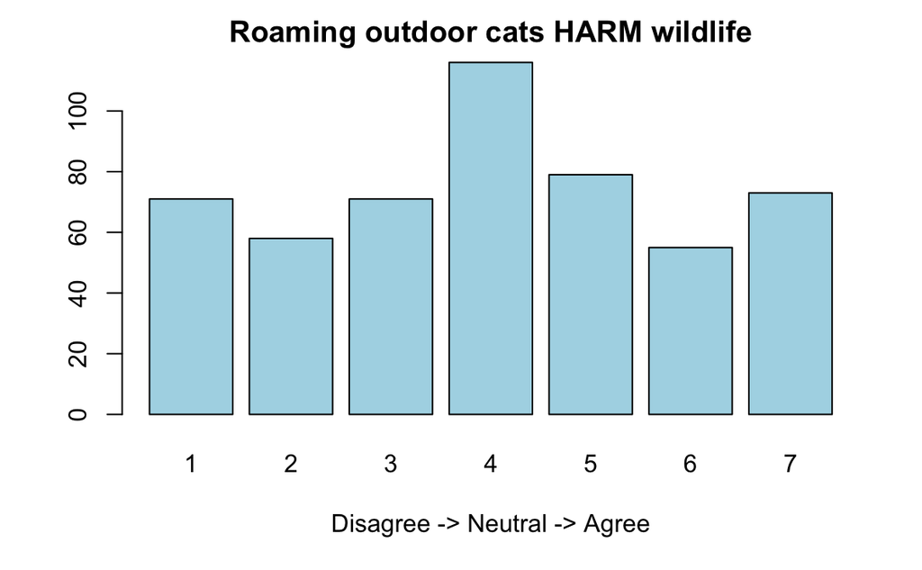

```r
library(car)
df <- read.csv(file = "Raw_Data.csv")
df$A1Num <- as.numeric(df$A1)
Q1A <- df[df[, "Q1"]=="Roaming outdoor cats harm wildlife",]
Q1A <- Q1A[, c(1,2,3,12:17)]
Q1A$A1Num <- recode(Q1A$A1Num,"1=6;2=2;3=4;4=5;5=3;6=7;7=1")
Q1B <- df[df[, "Q1"]=="Roaming outdoor cats do not harm wildlife",]
Q1B <- Q1B[, c(1,2,3,12:17)]
Q1B$A1Num <- recode(Q1B$A1Num,"1=2;2=6;3=4;4=3;5=5;6=1;7=7")
A <- as.numeric(Q1A$A1Num)
B <- as.numeric(Q1B$A1Num)
barplot(table(A), main = "Roaming outdoor cats HARM wildlife",xlab = "Disagree -> Neutral -> Agree",col = "light blue")
```

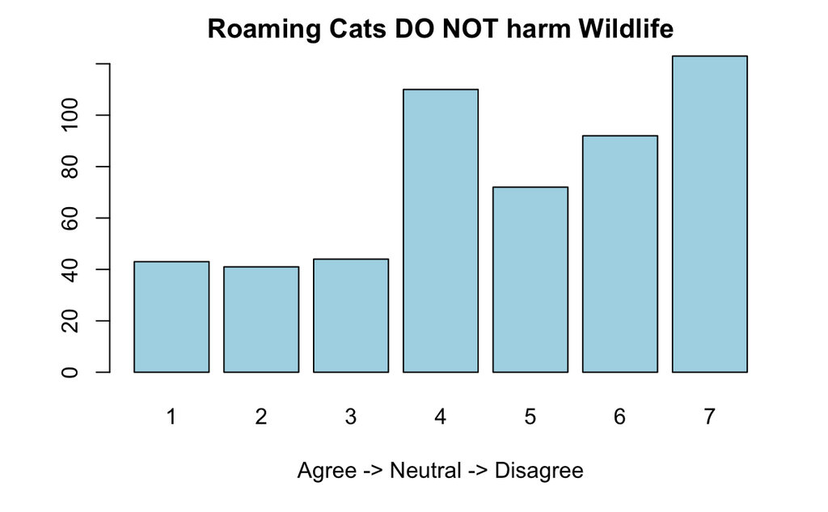

```r
barplot(table(B),main = "Roaming Cats DO NOT harm Wildlife",xlab = "Agree -> Neutral -> Disagree", col = "light blue")
```

```r
Data <- data.frame(
       WtAnswer=c(A, B),
       Question =factor(rep(c("A", "B"), times=c(length(A), length(B))))
       )
m <- aov(WtAnswer~Question,data = Data)
summary(m)
```

```
              Df Sum Sq Mean Sq F value  Pr(>F)
Question       1    125  124.54   34.47 5.8e-09 ***
Residuals   1046   3779    3.61
---
Signif. codes:  0 ‘***’ 0.001 ‘**’ 0.01 ‘*’ 0.05 ‘.’ 0.1 ‘ ’ 1
```

```r
shapiro.test(Data$WtAnswer)
```

```
    Shapiro-Wilk normality test

data:  Data$WtAnswer
W = 0.91976, p-value < 2.2e-16
```

```r
print("From the output, the p-value < 0.05 implying that the distribution of the data are  significantly different from normal distribution. In other words, we can NOT assume the normality.")
```

```
[1] "From the output, the p-value < 0.05 implying that the distribution of the data are  significantly different from normal distribution. In other words, we can NOT assume the normality."
```

```r
kruskal.test(WtAnswer ~ Question, data = Data)
```

```
    Kruskal-Wallis rank sum test

data:  WtAnswer by Question
Kruskal-Wallis chi-squared = 34.159, df = 1, p-value = 5.079e-09
```

```r
print("At .05 significance level, we conclude that the two questions have different answers.")
```

```
[1] "At .05 significance level, we conclude that the two questions have different answers."
```

```r
fligner.test(WtAnswer ~ Question, data = Data)
```

```
    Fligner-Killeen test of homogeneity of variances

data:  WtAnswer by Question
Fligner-Killeen:med chi-squared = 0.32674, df = 1, p-value = 0.5676
```

# Question 2: People should keep their cats indoors

A high number strongly agrees whereas a low number disagrees.

### Question 2A: People should keep their cats indoors or under a person’s control (e.g., leash, catio) while outdoorse.

Answers: Strongly Agree = 7 Moderately Agree = 6 Slightly Agree = 5 Neither Agree or Disagree = 4 Slightly Disagree = 3 Moderately Disagree = 2 Strongly Disagree = 1

### Question 2B: People need not keep their cats indoors or under a person’s control (e.g., leash, catio) while outdoors.

Answers: Strongly Agree = 1 Moderately Agree = 2 Slightly Agree = 3 Neither Agree or Disagree = 4 Slightly Disagree = 5 Moderately Disagree = 6 Strongly Disagree = 7

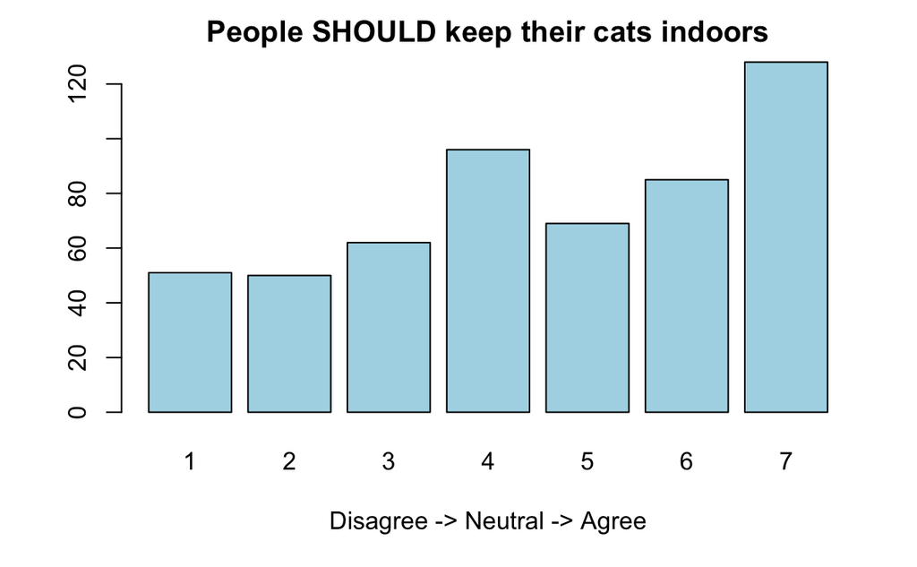

```r
df <- read.csv(file = "Raw_Data.csv")
df$A2Num <- as.numeric(df$A2)
Q2A <- df[df[, "Q2"]=="People should keep their cats indoors or under a person's control (e.g., leash, catio) while outdoors",]
Q2A <- Q2A[, c(1,4,5,12:17)]
Q2A$A2Num <- recode(Q2A$A2Num,"1=6;2=2;3=4;4=5;5=3;6=7;7=1")
Q2B <- df[df[, "Q2"]=="People need not keep their cats indoors or under a person's control (e.g., leash, catio) while outdoors",]
Q2B <- Q2B[, c(1,4,5,12:17)]
Q2B$A2Num <- recode(Q2B$A2Num,"1=2;2=6;3=4;4=3;5=5;6=1;7=7")
A <- as.numeric(Q2A$A2Num)
B <- as.numeric(Q2B$A2Num)
barplot(table(A), main = "People SHOULD keep their cats indoors",xlab = "Disagree -> Neutral -> Agree",col = "light blue")
```

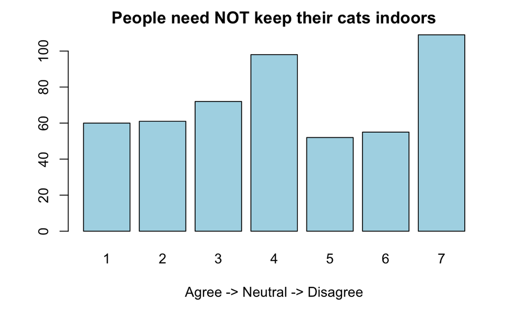

```r
barplot(table(B),main = "People need NOT keep their cats indoors",xlab = "Agree -> Neutral -> Disagree", col = "light blue")
```

```r
Data <- data.frame(
       WtAnswer=c(A, B),
       Question =factor(rep(c("A", "B"), times=c(length(A), length(B))))
       )
m <- aov(WtAnswer~Question,data = Data)
summary(m)
```

```
              Df Sum Sq Mean Sq F value  Pr(>F)
Question       1     31  30.700   7.665 0.00573 **
Residuals   1046   4190   4.005
---
Signif. codes:  0 ‘***’ 0.001 ‘**’ 0.01 ‘*’ 0.05 ‘.’ 0.1 ‘ ’ 1
```

```r
shapiro.test(Data$WtAnswer)
```

```
    Shapiro-Wilk normality test

data:  Data$WtAnswer
W = 0.90762, p-value < 2.2e-16
```

```r
print("From the output, the p-value < 0.05 implying that the distribution of the data are  significantly different from normal distribution. In other words, we can NOT assume the normality.")
```

```
[1] "From the output, the p-value < 0.05 implying that the distribution of the data are  significantly different from normal distribution. In other words, we can NOT assume the normality."
```

```r
kruskal.test(WtAnswer ~ Question, data = Data)
```

```
    Kruskal-Wallis rank sum test

data:  WtAnswer by Question
Kruskal-Wallis chi-squared = 7.4214, df = 1, p-value = 0.006445
```

```r
print("At .05 significance level, we conclude that the two questions have different answers.")
```

```
[1] "At .05 significance level, we conclude that the two questions have different answers."
```

# Question 3: Pet cats should be spayed or neutered

A high number strongly agrees whereas a low number disagrees.

### Question 3A: Pet cats should be spayed or neutered unless intended for breeding.

Answers: Strongly Agree = 7 Moderately Agree = 6 Slightly Agree = 5 Neither Agree or Disagree = 4 Slightly Disagree = 3 Moderately Disagree = 2 Strongly Disagree = 1

### Question 3B: Pet cats not intended for breeding need not be spayed or neutered.

Answers: Strongly Agree = 1 Moderately Agree = 2 Slightly Agree = 3 Neither Agree or Disagree = 4 Slightly Disagree = 5 Moderately Disagree = 6 Strongly Disagree = 7

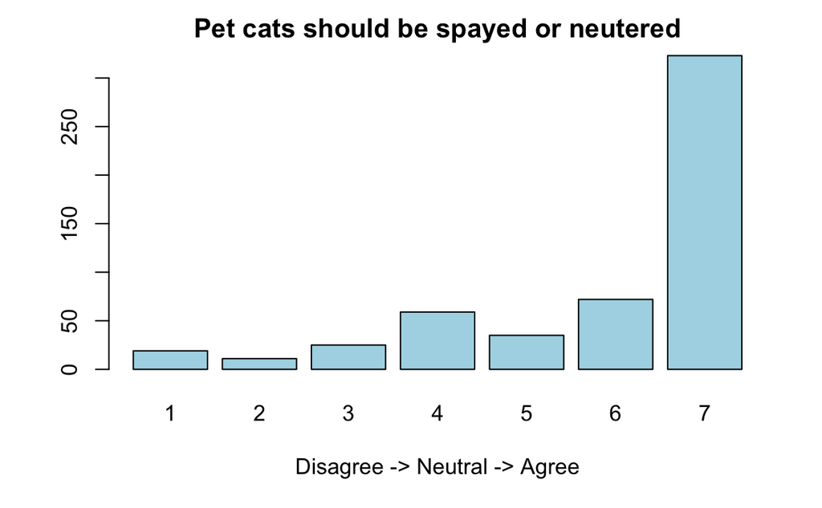

```r
df <- read.csv(file = "Raw_Data.csv")
df$A3Num <- as.numeric(df$A3)
Q3A <- df[df[, "Q3"]=="Pet cats should be spayed or neutered unless intended for breeding",]
Q3A <- Q3A[, c(1,6,7,12:17)]
Q3A$A3Num <- recode(Q3A$A3Num,"1=6;2=2;3=4;4=5;5=3;6=7;7=1")
Q3B <- df[df[, "Q3"]=="Pet cats not intended for breeding need not be spayed or neutered",]
Q3B <- Q3B[, c(1,6,7,12:17)]
Q3B$A3Num <- recode(Q3B$A3Num,"1=2;2=6;3=4;4=3;5=5;6=1;7=7")
A <- as.numeric(Q3A$A3Num)
B <- as.numeric(Q3B$A3Num)
barplot(table(A), main = "Pet cats should be spayed or neutered", xlab = "Disagree -> Neutral -> Agree",col = "light blue")
```

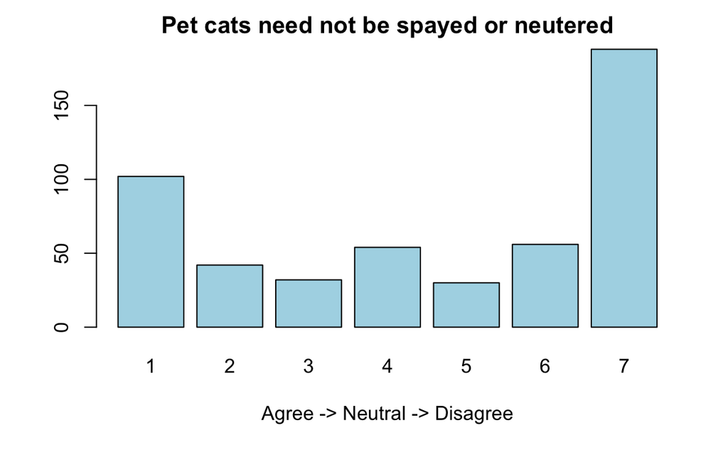

```r
barplot(table(B),main = "Pet cats need not be spayed or neutered",xlab = "Agree -> Neutral -> Disagree", col = "light blue")
```

```r
Data <- data.frame(
       WtAnswer=c(A, B),
       Question =factor(rep(c("A", "B"), times=c(length(A), length(B))))
       )
m <- aov(WtAnswer~Question,data = Data)
summary(m)
```

```
              Df Sum Sq Mean Sq F value Pr(>F)
Question       1    481   480.8   115.1 <2e-16 ***
Residuals   1046   4370     4.2
---
Signif. codes:  0 ‘***’ 0.001 ‘**’ 0.01 ‘*’ 0.05 ‘.’ 0.1 ‘ ’ 1
```

```r
shapiro.test(Data$WtAnswer)
```

```
    Shapiro-Wilk normality test

data:  Data$WtAnswer
W = 0.76684, p-value < 2.2e-16
```

```r
print("From the output, the p-value < 0.05 implying that the distribution of the data are  significantly different from normal distribution. In other words, we can NOT assume the normality.")
```

```
[1] "From the output, the p-value < 0.05 implying that the distribution of the data are  significantly different from normal distribution. In other words, we can NOT assume the normality."
```

```r
kruskal.test(WtAnswer ~ Question, data = Data)
```

```
    Kruskal-Wallis rank sum test

data:  WtAnswer by Question
Kruskal-Wallis chi-squared = 87.577, df = 1, p-value < 2.2e-16
```

```r
print("At .05 significance level, we conclude that the two questions have different answers.")
```

```
[1] "At .05 significance level, we conclude that the two questions have different answers."
```

# Question 4: Pet cats should be microchipped

A high number strongly agrees whereas a low number disagrees.

### Question 4A: Pet cats should be microchipped (a microchip is a small identification device inserted under the animal’s skin).

Answers: Strongly Agree = 7 Moderately Agree = 6 Slightly Agree = 5 Neither Agree or Disagree = 4 Slightly Disagree = 3 Moderately Disagree = 2 Strongly Disagree = 1

### Question 4B: Pet cats need not be microchipped (a microchip is a small identification device inserted under the animal’s skin).

Answers: Strongly Agree = 1 Moderately Agree = 2 Slightly Agree = 3 Neither Agree or Disagree = 4 Slightly Disagree = 5 Moderately Disagree = 6 Strongly Disagree = 7

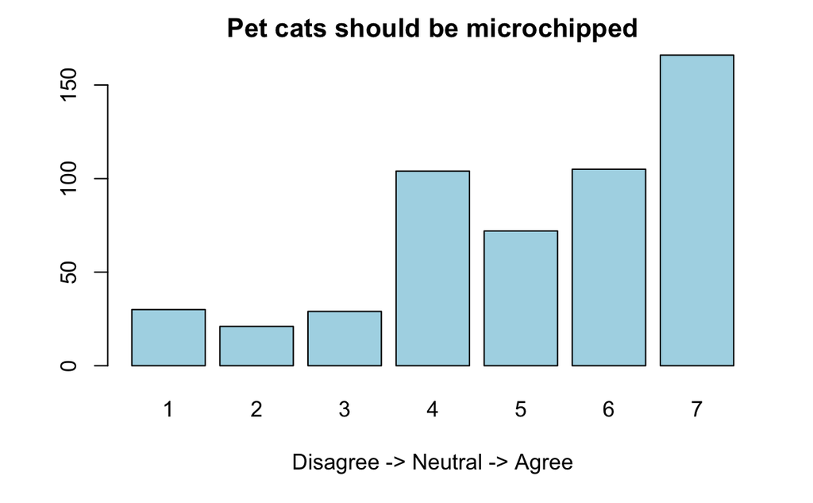

```r
df <- read.csv(file = "Raw_Data.csv")
df$A4Num <- as.numeric(df$A4)
Q4A <- df[df[,"Q4"]=="Pet cats should be microchipped (a microchip is a small identification device inserted under the animal's skin)<br>",]
Q4A <- Q4A[, c(1,8,9,12:17)]
Q4A$A4Num <- recode(Q4A$A4Num,"1=6;2=2;3=4;4=5;5=3;6=7;7=1")
Q4B <- df[df[, "Q4"]=="Pet cats need not be microchipped (a microchip is a small identification device inserted under the animal's skin)",]
Q4B <- Q4B[, c(1,8,9,12:17)]
Q4B$A4Num <- recode(Q4B$A4Num,"1=2;2=6;3=4;4=3;5=5;6=1;7=7")
A <- as.numeric(Q4A$A4Num)
B <- as.numeric(Q4B$A4Num)
barplot(table(A), main = "Pet cats should be microchipped", xlab = "Disagree -> Neutral -> Agree",col = "light blue")
```

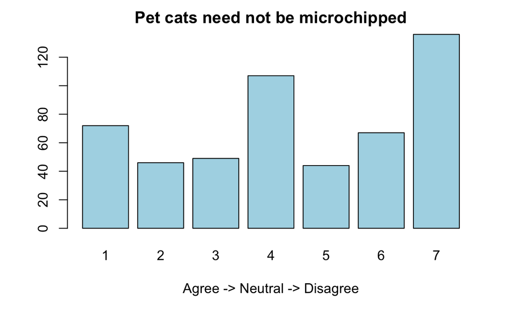

```r
barplot(table(B),main = "Pet cats need not be microchipped",xlab = "Agree -> Neutral -> Disagree", col = "light blue")
```

```r
Data <- data.frame(
       WtAnswer=c(A, B),
       Question =factor(rep(c("A", "B"), times=c(length(A), length(B))))
       )
m <- aov(WtAnswer~Question,data = Data)
summary(m)
```

```
              Df Sum Sq Mean Sq F value   Pr(>F)
Question       1    142  141.55   37.41 1.35e-09 ***
Residuals   1046   3958    3.78
---
Signif. codes:  0 ‘***’ 0.001 ‘**’ 0.01 ‘*’ 0.05 ‘.’ 0.1 ‘ ’ 1
```

```r
shapiro.test(Data$WtAnswer)
```

```
    Shapiro-Wilk normality test

data:  Data$WtAnswer
W = 0.88019, p-value < 2.2e-16
```

```r
print("From the output, the p-value < 0.05 implying that the distribution of the data are  significantly different from normal distribution. In other words, we can NOT assume the normality.")
```

```
[1] "From the output, the p-value < 0.05 implying that the distribution of the data are  significantly different from normal distribution. In other words, we can NOT assume the normality."
```

```r
kruskal.test(WtAnswer ~ Question, data = Data)
```

```
    Kruskal-Wallis rank sum test

data:  WtAnswer by Question
Kruskal-Wallis chi-squared = 29.942, df = 1, p-value = 4.452e-08
```

```r
print("At .05 significance level, we conclude that the two questions have different answers.")
```

```
[1] "At .05 significance level, we conclude that the two questions have different answers."
```

# Question 5: Roaming outdoor cats pose a risk to human health

A high number strongly agrees whereas a low number disagrees.

### Question 5A: Roaming outdoor cats pose a risk to human health.

Answers: Strongly Agree = 7 Moderately Agree = 6 Slightly Agree = 5 Neither Agree or Disagree = 4 Slightly Disagree = 3 Moderately Disagree = 2 Strongly Disagree = 1

### Question 5B: Roaming outdoor cats do not pose a risk to human health.

Answers: Strongly Agree = 1 Moderately Agree = 2 Slightly Agree = 3 Neither Agree or Disagree = 4 Slightly Disagree = 5 Moderately Disagree = 6 Strongly Disagree = 7

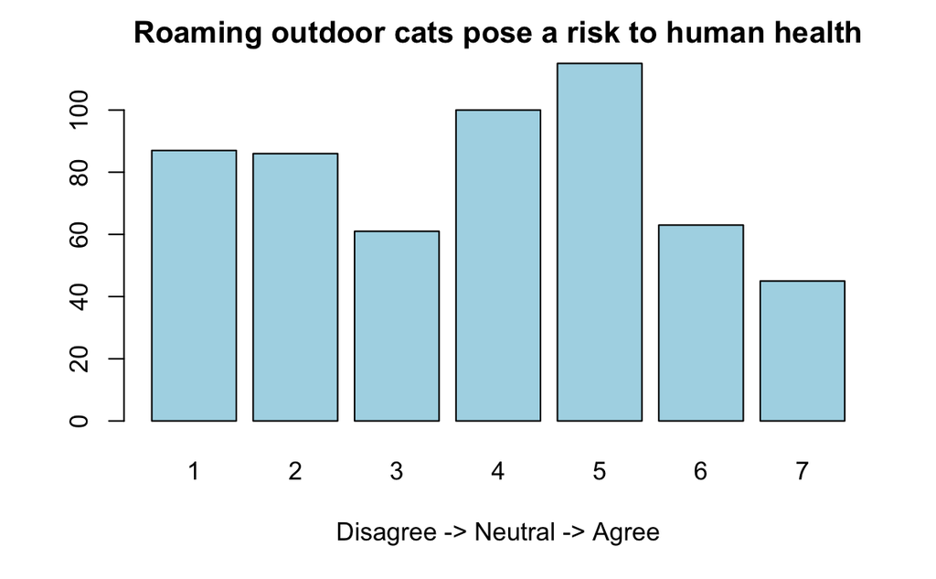

```r
df <- read.csv(file = "Raw_Data.csv")
df$A5Num <- as.numeric(df$A5)
Q5A <- df[df[,"Q5"]=="Roaming outdoor cats pose a risk to human health<br>",]
Q5A <- Q5A[, c(1,10,11,12:17)]
Q5A$A5Num <- recode(Q5A$A5Num,"1=6;2=2;3=4;4=5;5=3;6=7;7=1")
Q5B <- df[df[, "Q5"]=="Roaming outdoor cats do not pose a risk to human health",]
Q5B <- Q5B[, c(1,10,11,12:17)]
Q5B$A5Num <- recode(Q5B$A5Num,"1=2;2=6;3=4;4=3;5=5;6=1;7=7")
A <- as.numeric(Q5A$A5Num)
B <- as.numeric(Q5B$A5Num)
barplot(table(A), main = "Roaming outdoor cats pose a risk to human health", xlab = "Disagree -> Neutral -> Agree",col = "light blue")
```

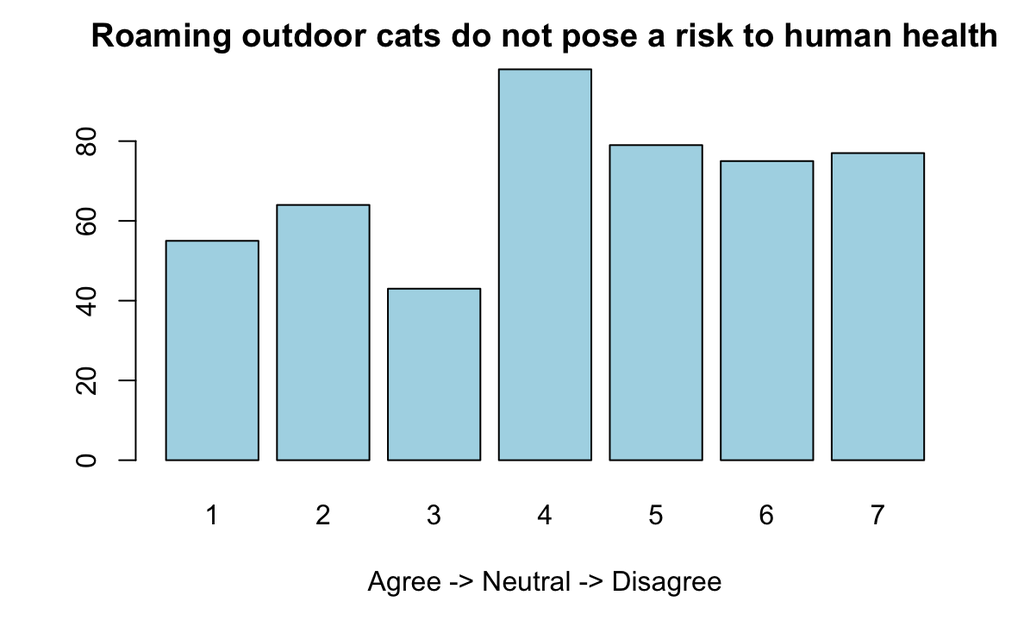

```r
barplot(table(B),main = "Roaming outdoor cats do not pose a risk to human health",xlab = "Agree -> Neutral -> Disagree", col = "light blue")
```

```r
Data <- data.frame(
       WtAnswer=c(A, B),
       Question =factor(rep(c("A", "B"), times=c(length(A), length(B))))
       )
m <- aov(WtAnswer~Question,data = Data)
summary(m)
```

```
              Df Sum Sq Mean Sq F value   Pr(>F)
Question       1     56   56.28   15.62 8.28e-05 ***
Residuals   1046   3770    3.60
---
Signif. codes:  0 ‘***’ 0.001 ‘**’ 0.01 ‘*’ 0.05 ‘.’ 0.1 ‘ ’ 1
```

```r
shapiro.test(Data$WtAnswer)
```

```
    Shapiro-Wilk normality test

data:  Data$WtAnswer
W = 0.92644, p-value < 2.2e-16
```

```r
print("From the output, the p-value < 0.05 implying that the distribution of the data are  significantly different from normal distribution. In other words, we can NOT assume the normality.")
```

```
[1] "From the output, the p-value < 0.05 implying that the distribution of the data are  significantly different from normal distribution. In other words, we can NOT assume the normality."
```

```r
kruskal.test(WtAnswer ~ Question, data = Data)
```

```
    Kruskal-Wallis rank sum test

data:  WtAnswer by Question
Kruskal-Wallis chi-squared = 14.935, df = 1, p-value = 0.0001113
```

```r
print("At .05 significance level, we conclude that the two questions have different answers.")
```

```
[1] "At .05 significance level, we conclude that the two questions have different answers."
```